# Analyse en Composantes Principales

Jeu de données data_bwd_fwd_2019

Ce jeu de données contient 24 individus et 34 variables, 17 variables quantitatives sont illustratives.

### 1. Observation d’individus extrêmes

L’analyse des graphes détecte des individus singuliers qui influencent très fortement les résultats observés. On soulignera dans un premier temps le caractère extrême de ces individus avant de les retirer pour procéder à la suite de l’analyse. En observant le graphe, on peut noter que 4 individus sont très particuliers et contribuent énormément à la construction du plan. Le cumul de leur contribution à la contruction du plan atteint **70.1%**.

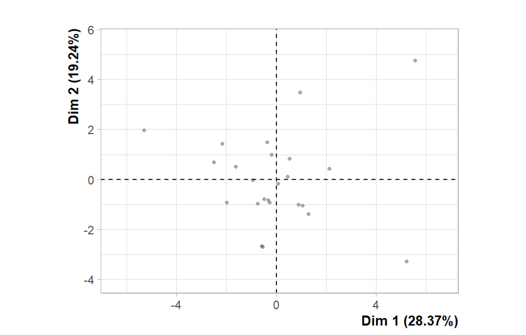

**Figure 1.1 - Graphe des individus (ACP) avant correction.** *Mise en évidence de 4 individus singuliers.*

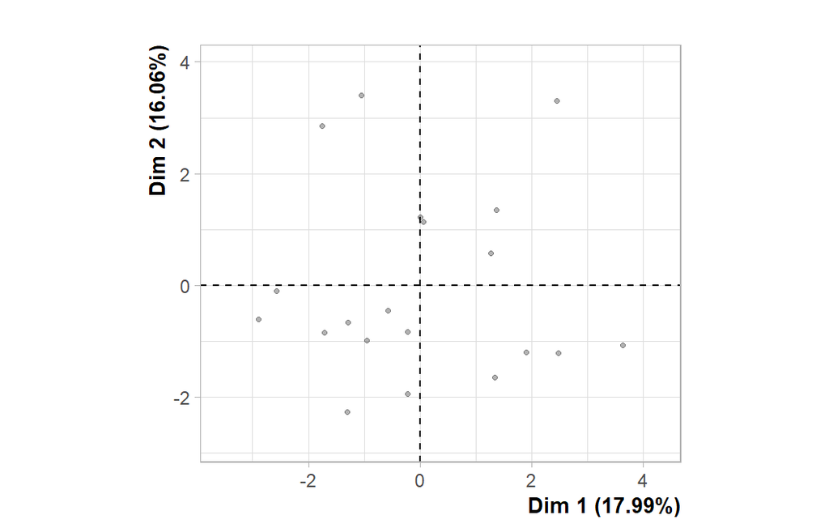

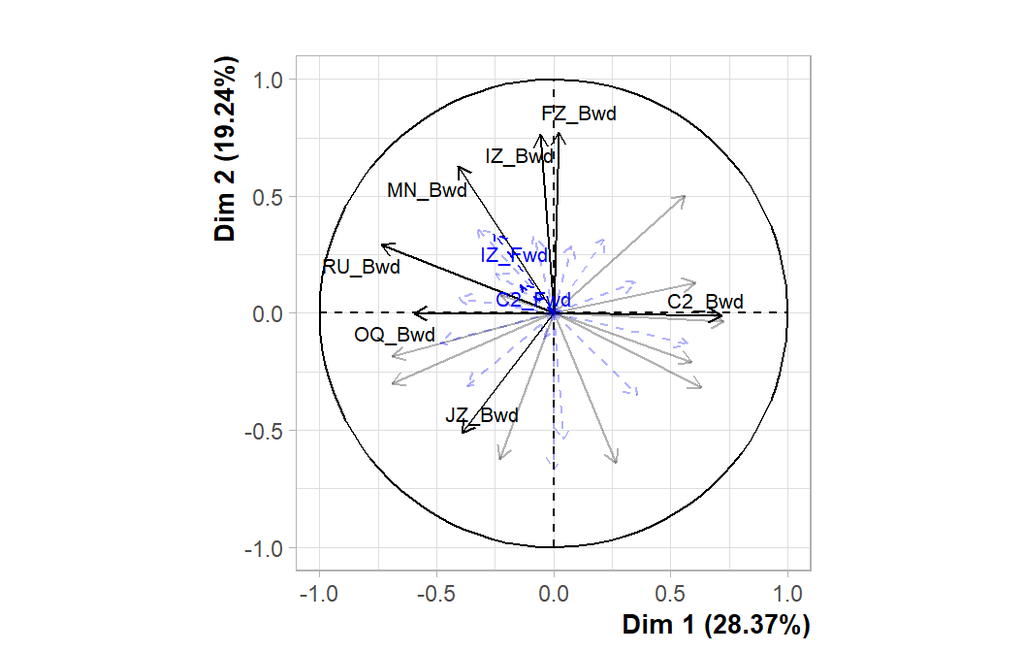

**Figure 1.3 - Graphe des variables (ACP) avant correction** *Les variables libellées sont celles les mieux représentées sur le plan.*

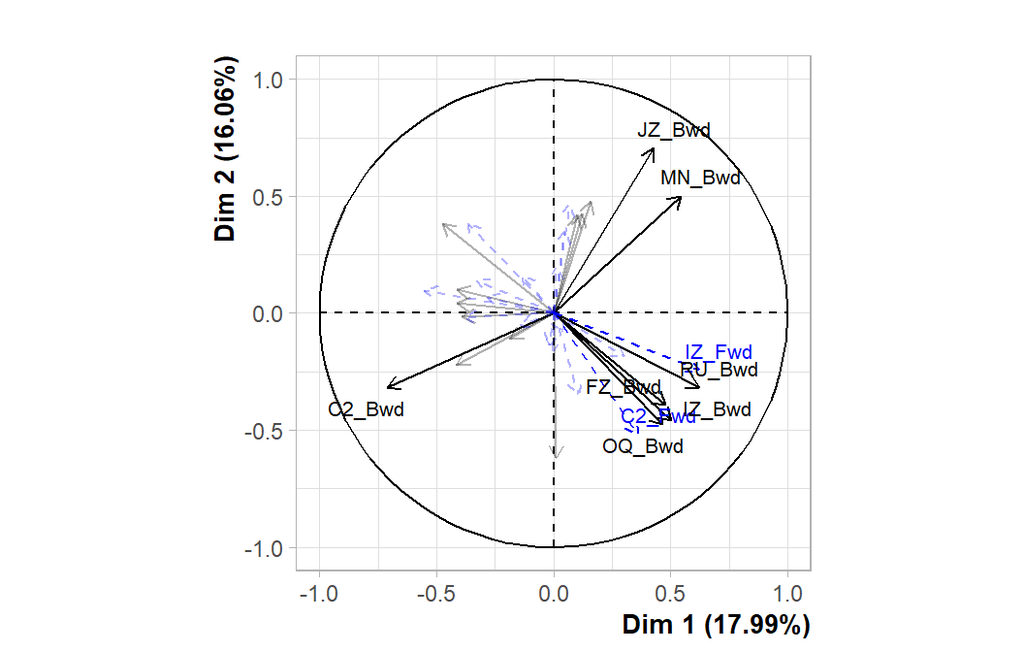

**Figure 1.3 - Graphe des variables (ACP) après correction**

**L’individu 14** :

- prend de très fortes valeurs pour le(s) variable(s) : *HZ_Bwd* et *IZ_Bwd* (de la plus extrême à la moins extrême).
- prend de très faibles valeurs pour les variables : *GZ_Bwd*, *JZ_Bwd*, *AZ_Bwd* et *OQ_Bwd* (de la plus extrême à la moins extrême).

**L’individu 19** :

- prend de très fortes valeurs pour le(s) variable(s) : *C3_Bwd* et *C4_Bwd* (de la plus extrême à la moins extrême).
- prend de très faibles valeurs pour les variables : *MN_Bwd* et *LZ_Bwd* (de la plus extrême à la moins extrême).

**L’individu 6** :

- prend de très fortes valeurs pour le(s) variable(s) : *OQ_Bwd* et *RU_Bwd* (de la plus extrême à la moins extrême).
- prend de très faibles valeurs pour les variables : *C1_Bwd* et *C5_Bwd* (de la plus extrême à la moins extrême).

### 2. Distribution de l’inertie

L’inertie des axes factoriels indique d’une part si les variables sont structurées et suggère d’autre part le nombre judicieux de composantes principales à étudier.

Les 2 premiers axes de l’ analyse expriment **34.05%** de l’inertie totale du jeu de données ; cela signifie que 34.05% de la variabilité totale du nuage des individus (ou des variables) est représentée dans ce plan. L’inertie observée sur le premier plan factoriel est inférieure à la valeur référence de **36.88%**, et donc faible en comparaison (cette intertie de référence est le quantile 0.95-quantile de la distribution des pourcentages d’inertie obtenue en simulant 6373 jeux de données aléatoires de dimensions comparables sur la base d’une distribution normale). De plus, l’inertie observée sur la première composante principale est inférieure à la valeur de référence **21.09%**. La variabilité exprimée par l’ analyse **n’est donc pas** significative.

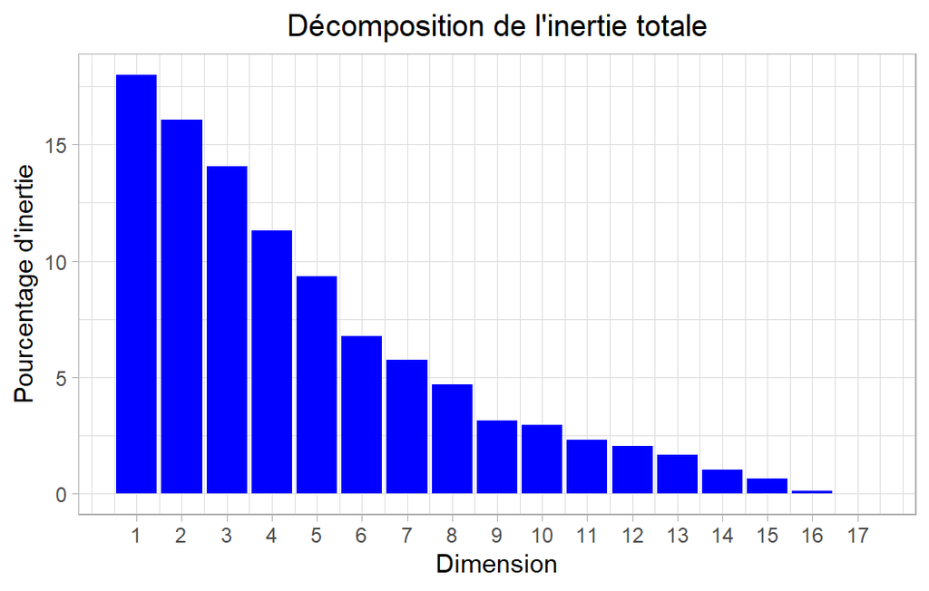

**Figure 2 - Décomposition de l’inertie totale**

### 3. Description de la dimension 1

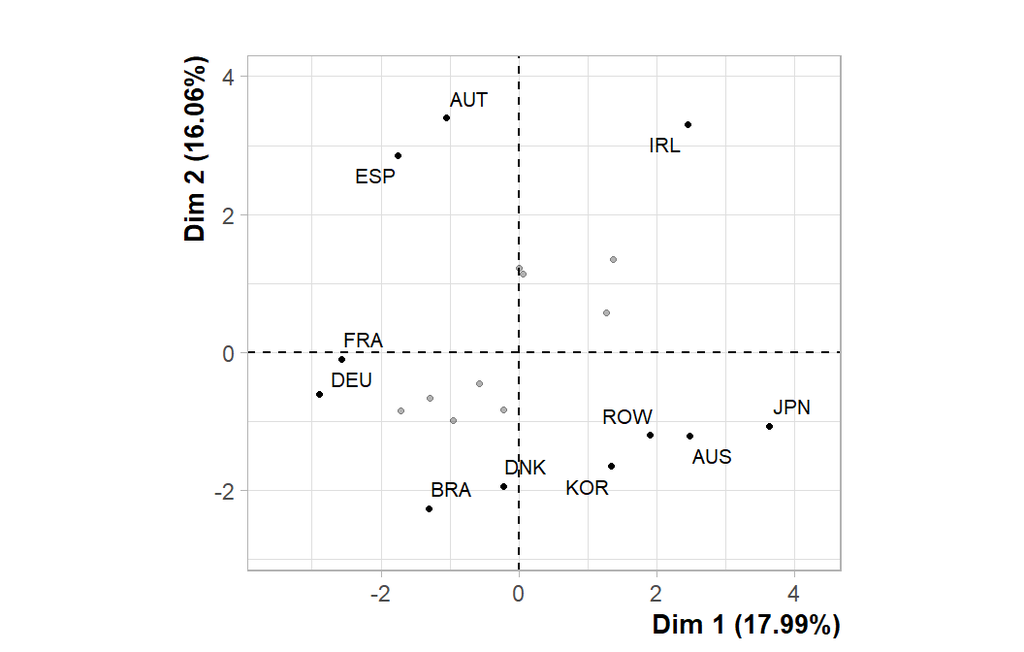

**Figure 3.1 - Graphe des individus (ACP)** *Les individus libellés sont ceux ayant la plus grande contribution à la construction du plan.*

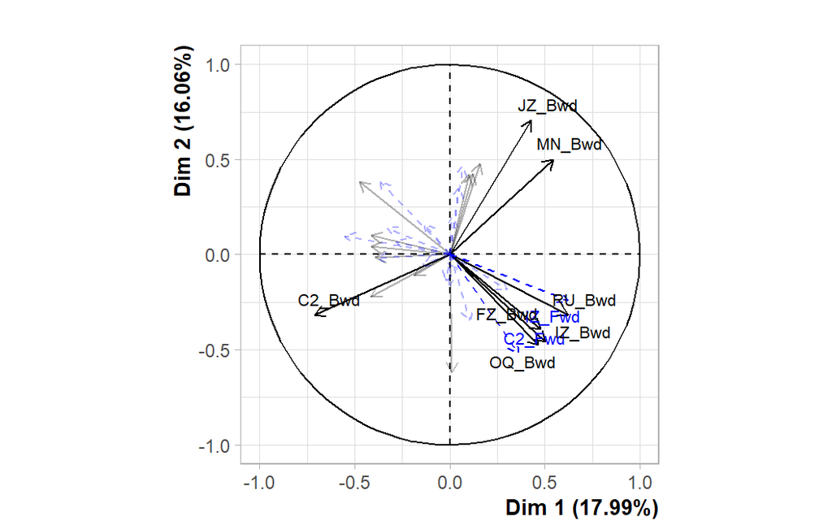

**Figure 3.2 - Graphe des variables (ACP)** *Les variables en noir sont les variables actives, celles en bleu sont les variables quantitatives supplémentaires (illustratives).* *Les variables libellées sont celles les mieux représentées sur le plan.*

La **dimension 1** oppose des individus tels que *JPN*, *AUS*, *KOR* et *ROW* (à droite du graphe, caractérisés par une coordonnée fortement positive sur l’axe) à des individus comme *FRA*, *DEU*, *BRA* et *DNK* (à gauche du graphe, caractérisés par une coordonnée fortement négative sur l’axe).

Le groupe auquel les individus *JPN*, *AUS*, *KOR* et *ROW* appartiennent (caractérisés par une coordonnée positive sur l’axe) partage :

- de fortes valeurs pour les variables *OQ_Bwd*, *RU_Bwd*, *FZ_Bwd* et *C2_Fwd* (de la plus extrême à la moins extrême).
- de faibles valeurs pour les variables *C1_Bwd* et *HZ_Fwd* (de la plus extrême à la moins extrême).

Le groupe auquel les individus *FRA*, *DEU*, *BRA* et *DNK* appartiennent (caractérisés par une coordonnées négative sur l’axe) partage :

- de fortes valeurs pour les variables *AZ_Bwd*, *C2_Bwd* et *KZ_Bwd* (de la plus extrême à la moins extrême).
- de faibles valeurs pour les variables *MN_Bwd* et *JZ_Bwd* (de la plus extrême à la moins extrême).

La **dimension 2** oppose des individus tels que *ESP*, *AUT* et *IRL* (en haut du graphe, caractérisés par une coordonnées fortement positive sur l’axe) à des individus comme *JPN*, *FRA*, *DEU*, *AUS*, *KOR*, *BRA*, *ROW* et *DNK* (en bas du graphe, caractérisés par une coordonnées fortement négative sur l’axe).

Le groupe auquel les individus *ESP*, *AUT* et *IRL* appartiennent (caractérisés par une coordonnée positive sur l’axe) partage :

- de fortes valeurs pour les variables *JZ_Bwd*, *MN_Bwd* et *DE_Bwd* (de la plus extrême à la moins extrême).
- de faibles valeurs pour les variables *AZ_Bwd*, *OQ_Bwd* et *HZ_Bwd* (de la plus extrême à la moins extrême).

Le groupe auquel les individus *FRA*, *DEU*, *BRA* et *DNK* appartiennent (caractérisés par une coordonnées négative sur l’axe) partage :

- de fortes valeurs pour les variables *AZ_Bwd*, *C2_Bwd* et *KZ_Bwd* (de la plus extrême à la moins extrême).
- de faibles valeurs pour les variables *MN_Bwd* et *JZ_Bwd* (de la plus extrême à la moins extrême).

Le groupe auquel les individus *JPN*, *AUS*, *KOR* et *ROW* appartiennent (caractérisés par une coordonnées négative sur l’axe) partage :

- de fortes valeurs pour les variables *OQ_Bwd*, *RU_Bwd*, *FZ_Bwd* et *C2_Fwd* (de la plus extrême à la moins extrême).
- de faibles valeurs pour les variables *C1_Bwd* et *HZ_Fwd* (de la plus extrême à la moins extrême).